# Course Project 1

Nate Halsey

5/5/2019

# Introduction

It is now possible to collect a large amount of data about personal movement using activity monitoring devices such as a Fitbit, Nike Fuelband, or Jawbone Up. These type of devices are part of the “quantified self” movement – a group of enthusiasts who take measurements about themselves regularly to improve their health, to find patterns in their behavior, or because they are tech geeks. But these data remain under-utilized both because the raw data are hard to obtain and there is a lack of statistical methods and software for processing and interpreting the data.

This assignment makes use of data from a personal activity monitoring device. This device collects data at 5 minute intervals through out the day. The data consists of two months of data from an anonymous individual collected during the months of October and November, 2012 and include the number of steps taken in 5 minute intervals each day.

The data for this assignment can be downloaded from the course web site:

- Dataset [52K]: [Activity monitoring data[(https://d396qusza40orc.cloudfront.net/repdata%2Fdata%2Factivity.zip)

The variables included in this dataset are:

- steps: Number of steps taking in a 5-minute interval (missing values are coded as NA)
- date: The date on which the measurement was taken in YYYY-MM-DD format
- interval: Identifier for the 5-minute interval in which measurement was taken

The dataset is stored in a comma-separated-value (CSV) file and there are a total of 17,568 observations in this dataset.

## Review criteria

Repo

1. Valid GitHub URL
2. At least one commit beyond the original fork
3. Valid SHA-1
4. SHA-1 corresponds to a specific commit

Commit containing full submission

1. Code for reading in the dataset and/or processing the data
2. Histogram of the total number of steps taken each day
3. Mean and median number of steps taken each day
4. Time series plot of the average number of steps taken
5. The 5-minute interval that, on average, contains the maximum number of steps
6. Code to describe and show a strategy for imputing missing data
7. Histogram of the total number of steps taken each day after missing values are imputed
8. Panel plot comparing the average number of steps taken per 5-minute interval across weekdays and weekends
9. All of the R code needed to reproduce the results (numbers, plots, etc.) in the report

## Assignment

This assignment will be described in multiple parts. You will need to write a report that answers the questions detailed below. Ultimately, you will need to complete the entire assignment in a single R markdown document that can be processed by knitr and be transformed into an HTML file.

Throughout your report make sure you always include the code that you used to generate the output you present. When writing code chunks in the R markdown document, always use echo=TRUE so that someone else will be able to read the code. This assignment will be evaluated via peer assessment so it is essential that your peer evaluators be able to review the code for your analysis.

For the plotting aspects of this assignment, feel free to use any plotting system in R (i.e., base, lattice, ggplot2)

Fork/clone the GitHub repository created for this assignment. You will submit this assignment by pushing your completed files into your forked repository on GitHub. The assignment submission will consist of the URL to your GitHub repository and the SHA-1 commit ID for your repository state.

NOTE: The GitHub repository also contains the dataset for the assignment so you do not have to download the data separately.

### Collect, load, process, and evaluate the data

Collect and unzip data from data source

```r
fileUrl <- 'https://d396qusza40orc.cloudfront.net/repdata%2Fdata%2Factivity.zip'
download.file(fileUrl,destfile=paste0(getwd(),'/repdata%2Fdata%2Factivity.zip'),method='curl')
unzip('repdata%2Fdata%2Factivity.zip',exdir='data')
```

1. Load data

```r
activity <- read.csv('data/activity.csv',header=TRUE)
```

2. Evaluate data set
- Evaluate dimensions of the activity data set

```r
dim(activity)
```

```
## [1] 17568     3
```

- Evaluate structure of the activity data set

```r
str(activity)
```

```
## 'data.frame':    17568 obs. of  3 variables:
##  $ steps   : int  NA NA NA NA NA NA NA NA NA NA ...
##  $ date    : Factor w/ 61 levels "2012-10-01","2012-10-02",..: 1 1 1 1 1 1 1 1 1 1 ...
##  $ interval: int  0 5 10 15 20 25 30 35 40 45 ...
```

- Evaluate summary for the activity data set

```r
summary(activity)
```

```
##      steps                date          interval
##  Min.   :  0.00   2012-10-01:  288   Min.   :   0.0
##  1st Qu.:  0.00   2012-10-02:  288   1st Qu.: 588.8
##  Median :  0.00   2012-10-03:  288   Median :1177.5
##  Mean   : 37.38   2012-10-04:  288   Mean   :1177.5
##  3rd Qu.: 12.00   2012-10-05:  288   3rd Qu.:1766.2
##  Max.   :806.00   2012-10-06:  288   Max.   :2355.0
##  NA's   :2304     (Other)   :15840
```

- Evaluate head for the activity data set

```r
head(activity)
```

```
##   steps       date interval
## 1    NA 2012-10-01        0
## 2    NA 2012-10-01        5
## 3    NA 2012-10-01       10
## 4    NA 2012-10-01       15
## 5    NA 2012-10-01       20
## 6    NA 2012-10-01       25
```

- Evaluate tail for the activity data set

```r
tail(activity)
```

```
##       steps       date interval
## 17563    NA 2012-11-30     2330
## 17564    NA 2012-11-30     2335
## 17565    NA 2012-11-30     2340
## 17566    NA 2012-11-30     2345
## 17567    NA 2012-11-30     2350
## 17568    NA 2012-11-30     2355
```

### What is mean total number of steps taken per day?

Transform activity data set and remove NAs

```r
activity_data <- na.omit(activity)
```

1. Total number of steps taken per day

```r
library(dplyr)
daily_steps <- group_by(activity_data,date)
daily_steps <- summarize(daily_steps,steps=sum(steps))
summary(daily_steps)
```

```
##          date        steps
##  2012-10-02: 1   Min.   :   41
##  2012-10-03: 1   1st Qu.: 8841
##  2012-10-04: 1   Median :10765
##  2012-10-05: 1   Mean   :10766
##  2012-10-06: 1   3rd Qu.:13294
##  2012-10-07: 1   Max.   :21194
##  (Other)   :47
```

2. Make a histogram of the total number of steps taken each day

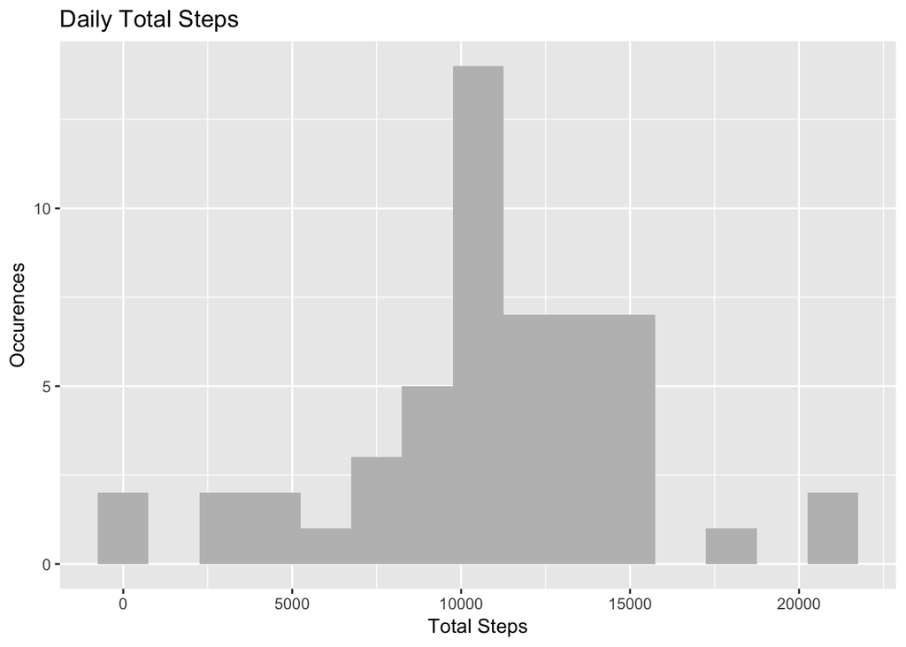

```r
library(ggplot2)
ggplot(daily_steps,aes(x=steps)) +
    geom_histogram(binwidth=1500,fill="gray") +
    labs(title = "Daily Total Steps", x = "Total Steps", y = "Occurences")
```

3. Calculate and report the mean of the total number of steps taken per day

```r
mean(na.omit(daily_steps$steps))
```

```
## [1] 10766.19
```

4. Calculate and report the median of the total number of steps taken per day

```r
median(na.omit(daily_steps$steps))
```

```
## [1] 10765
```

### What is the average daily activity pattern?

1. Time series plot (i.e. type = ‘1’) of the 5-minute interval (x-axis) and the average number of steps taken, averaged across all days (y-axis)

Process data frame for avg steps in 5 minute intervals and plot average steps by interval

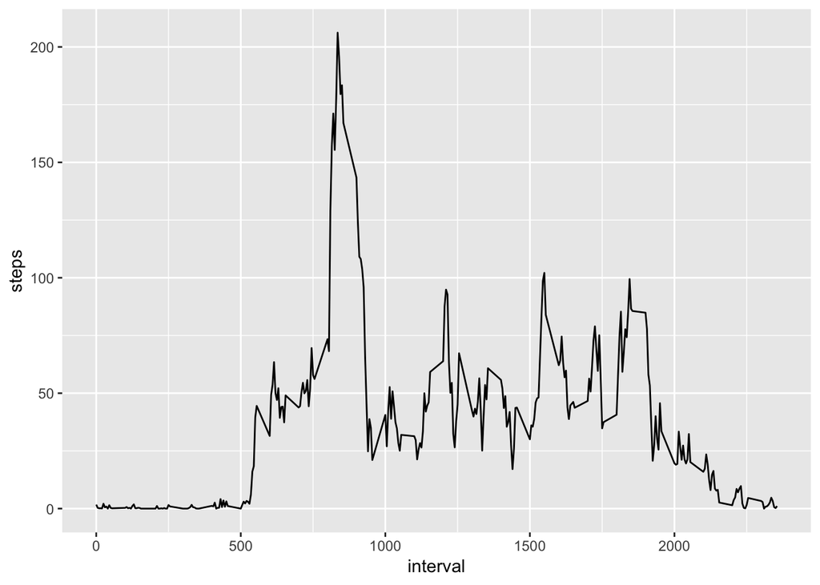

```r
daily_steps_int <- group_by(activity_data,interval)
daily_steps_int <- summarize(daily_steps_int,steps=mean(steps))
ggplot(daily_steps_int,aes(interval,steps))+geom_line()
```

2. Which 5-minute interval, on average across all the days in the dataset, contains the maximum number of steps?

```r
daily_steps_int[which(daily_steps_int$steps==max(daily_steps_int$steps)),]
```

```
## # A tibble: 1 x 2
##   interval steps
##      <int> <dbl>
## 1      835  206.
```

### Imputing missing values

1. Note that there are a number of days/intervals where there are missing values (coded as NA). The presence of missing days may introduce bias into some calculations or summaries of the data.

Calculate and report the total number of missing values in the dataset (i.e. the total number of rows with NAs)

```r
sapply(X=activity,FUN=function(x)sum(is.na(x)))
```

```
##    steps     date interval
##     2304        0        0
```

2. Devise a strategy for filling in all of the missing values in the dataset. The strategy does not need to be sophisticated. For example, you could use the mean/median for that day, or the mean for that 5-minute interval, etc.
- The mean value substitution is the selected strategy

Measure NA distribution by interval and date

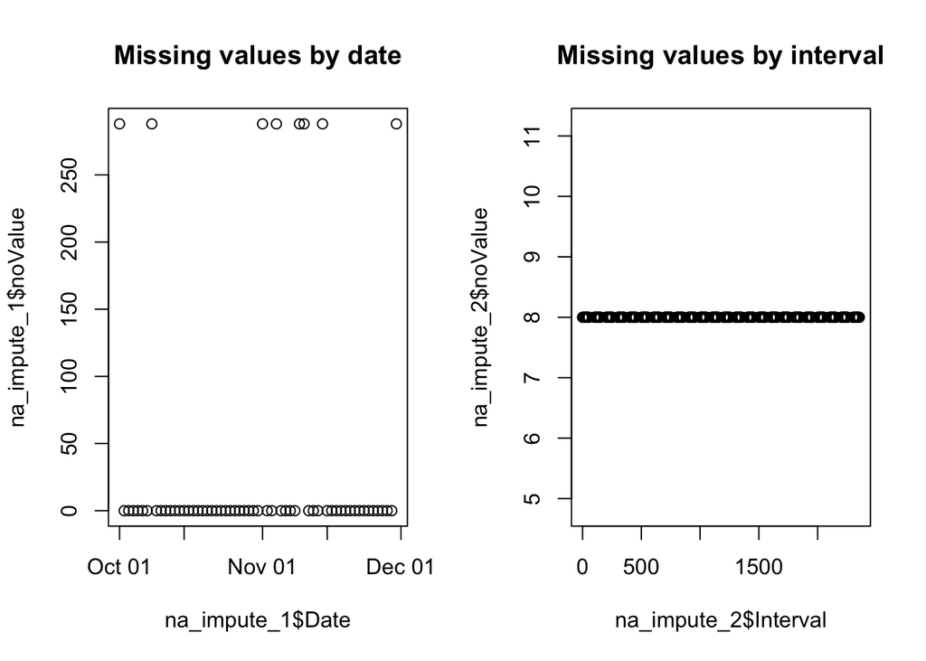

```r
na_impute <- activity
na_impute$noValue <- is.na(na_impute$steps)
na_impute <- aggregate(data=na_impute,noValue~date+interval,FUN="sum")
na_impute_1 <- data.frame(tapply(na_impute$noValue,na_impute$date,sum))
na_impute_1$date <- rownames(na_impute_1)
rownames(na_impute_1) <- NULL
names(na_impute_1) <- c("noValue","Date")
na_impute_1$Date <- as.Date(na_impute_1$Date,format="%Y-%m-%d")

na_impute_2 <- data.frame(tapply(na_impute$noValue,na_impute$interval,sum))
na_impute_2$date <- rownames(na_impute_2)
rownames(na_impute_2) <- NULL
names(na_impute_2) <- c("noValue","Interval")

par(mfrow=c(1,2))
plot(y=na_impute_1$noValue,x=na_impute_1$Date,main="Missing values by date")
plot(y=na_impute_2$noValue,x=na_impute_2$Interval,main="Missing values by interval")
```

```r
table(activity$date)
```

```
##
## 2012-10-01 2012-10-02 2012-10-03 2012-10-04 2012-10-05 2012-10-06
##        288        288        288        288        288        288
## 2012-10-07 2012-10-08 2012-10-09 2012-10-10 2012-10-11 2012-10-12
##        288        288        288        288        288        288
## 2012-10-13 2012-10-14 2012-10-15 2012-10-16 2012-10-17 2012-10-18
##        288        288        288        288        288        288
## 2012-10-19 2012-10-20 2012-10-21 2012-10-22 2012-10-23 2012-10-24
##        288        288        288        288        288        288
## 2012-10-25 2012-10-26 2012-10-27 2012-10-28 2012-10-29 2012-10-30
##        288        288        288        288        288        288
## 2012-10-31 2012-11-01 2012-11-02 2012-11-03 2012-11-04 2012-11-05
##        288        288        288        288        288        288
## 2012-11-06 2012-11-07 2012-11-08 2012-11-09 2012-11-10 2012-11-11
##        288        288        288        288        288        288
## 2012-11-12 2012-11-13 2012-11-14 2012-11-15 2012-11-16 2012-11-17
##        288        288        288        288        288        288
## 2012-11-18 2012-11-19 2012-11-20 2012-11-21 2012-11-22 2012-11-23
##        288        288        288        288        288        288
## 2012-11-24 2012-11-25 2012-11-26 2012-11-27 2012-11-28 2012-11-29
##        288        288        288        288        288        288
## 2012-11-30
##        288
```

Measurement observations:

- There are 8 missing values per each interval
- There are 288 missing values for date
3. Create a new dataset that is equal to the original dataset but with the missing data filled in.

Merge transformed daily_steps_int data with the original activity data

```r
names(daily_steps_int)[2] <- "steps_mean"
activity_impute <- merge(activity, daily_steps_int)
str(activity_impute)
```

```
## 'data.frame':    17568 obs. of  4 variables:
##  $ interval  : int  0 0 0 0 0 0 0 0 0 0 ...
##  $ steps     : int  NA 0 0 0 0 0 0 0 0 0 ...
##  $ date      : Factor w/ 61 levels "2012-10-01","2012-10-02",..: 1 54 28 37 55 46 20 47 38 56 ...
##  $ steps_mean: num  1.72 1.72 1.72 1.72 1.72 ...
```

Replace NAs with mean steps by interval

```r
activity_impute$steps[is.na(activity_impute$steps)] <- activity_impute$steps_mean[is.na(activity_impute$steps)]
str(activity_impute)
```

```
## 'data.frame':    17568 obs. of  4 variables:
##  $ interval  : int  0 0 0 0 0 0 0 0 0 0 ...
##  $ steps     : num  1.72 0 0 0 0 ...
##  $ date      : Factor w/ 61 levels "2012-10-01","2012-10-02",..: 1 54 28 37 55 46 20 47 38 56 ...
##  $ steps_mean: num  1.72 1.72 1.72 1.72 1.72 ...
```

4. Make a histogram of the total number of steps taken each day and Calculate and report the mean and median total number of steps taken per day. Do these values differ from the estimates from the first part of the assignment? What is the impact of imputing missing data on the estimates of the total daily number of steps?

Transform activity_impute data set to calculate total steps by day

```r
act_imp_day_steps <- group_by(activity_impute,date)
act_imp_day_steps <- summarize(act_imp_day_steps,steps=sum(steps))
str(act_imp_day_steps)
```

```
## Classes 'tbl_df', 'tbl' and 'data.frame':    61 obs. of  2 variables:
##  $ date : Factor w/ 61 levels "2012-10-01","2012-10-02",..: 1 2 3 4 5 6 7 8 9 10 ...
##  $ steps: num  10766 126 11352 12116 13294 ...
```

Histogram plot of act_imp_day_steps data set

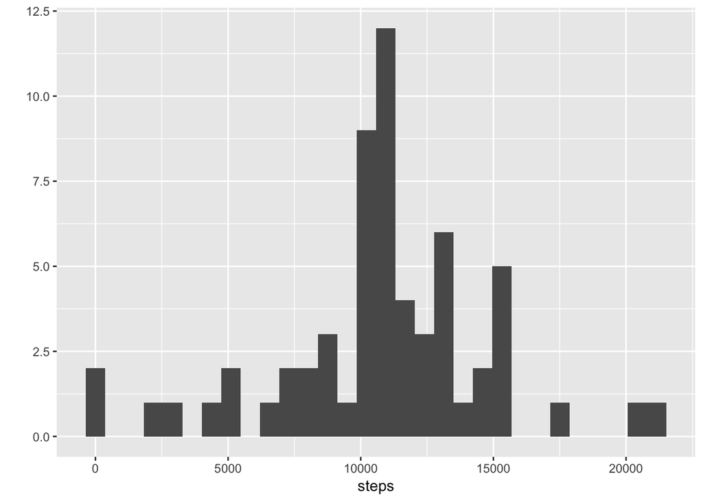

```r
qplot(steps,data=act_imp_day_steps)
```

Measure mean value act_imp_day_steps

```r
mean(act_imp_day_steps$steps)
```

```
## [1] 10766.19
```

Measure median value act_imp_day_steps

```r
median(act_imp_day_steps$steps)
```

```
## [1] 10766.19
```

Observations:

- Mean is the same
- Median is slightly higher

### Are there differences in activity patterns between weekdays and weekends?

1. Create a new factor variable in the dataset with two levels – “weekday” and “weekend” indicating whether a given date is a weekday or weekend day.

Convert date class, use weekdays() function to assign day of week to date.

```r
activity_impute$day <- weekdays(as.Date(activity_impute$date))
activity_impute$weekend <-as.factor(activity_impute$day=="Saturday"|activity_impute$day=="Sunday")
levels(activity_impute$weekend) <- c("Weekday", "Weekend")
str(activity_impute)
```

```
## 'data.frame':    17568 obs. of  6 variables:
##  $ interval  : int  0 0 0 0 0 0 0 0 0 0 ...
##  $ steps     : num  1.72 0 0 0 0 ...
##  $ date      : Factor w/ 61 levels "2012-10-01","2012-10-02",..: 1 54 28 37 55 46 20 47 38 56 ...
##  $ steps_mean: num  1.72 1.72 1.72 1.72 1.72 ...
##  $ day       : chr  "Monday" "Friday" "Sunday" "Tuesday" ...
##  $ weekend   : Factor w/ 2 levels "Weekday","Weekend": 1 1 2 1 2 1 2 1 1 2 ...
```

2. Make a panel plot containing a time series plot (i.e. type=“l”) of the 5-minute interval (x-axis) and the average number of steps taken, averaged across all weekday days or weekend days (y-axis). See the README file in the GitHub repository to see an example of what this plot should look like using simulated data.

Process data sets for each of Weekend and Weekday

```r
activity_weekday <- activity_impute[activity_impute$weekend=="Weekday",]
str(activity_weekday)
```

```
## 'data.frame':    12960 obs. of  6 variables:
##  $ interval  : int  0 0 0 0 0 0 0 0 0 0 ...
##  $ steps     : num  1.72 0 0 0 0 ...
##  $ date      : Factor w/ 61 levels "2012-10-01","2012-10-02",..: 1 54 37 46 47 38 39 12 30 57 ...
##  $ steps_mean: num  1.72 1.72 1.72 1.72 1.72 ...
##  $ day       : chr  "Monday" "Friday" "Tuesday" "Thursday" ...
##  $ weekend   : Factor w/ 2 levels "Weekday","Weekend": 1 1 1 1 1 1 1 1 1 1 ...
```

```r
activity_weekend <- activity_impute[activity_impute$weekend=="Weekend",]
str(activity_weekend)
```

```
## 'data.frame':    4608 obs. of  6 variables:
##  $ interval  : int  0 0 0 0 0 0 0 0 0 0 ...
##  $ steps     : num  0 0 0 0 1.72 ...
##  $ date      : Factor w/ 61 levels "2012-10-01","2012-10-02",..: 28 55 20 56 35 49 14 6 42 7 ...
##  $ steps_mean: num  1.72 1.72 1.72 1.72 1.72 ...
##  $ day       : chr  "Sunday" "Saturday" "Saturday" "Sunday" ...
##  $ weekend   : Factor w/ 2 levels "Weekday","Weekend": 2 2 2 2 2 2 2 2 2 2 ...
```

Measure mean steps per interval

```r
activity_weekday_int <- group_by(activity_weekday, interval)
activity_weekday_int <- summarize(activity_weekday_int, steps=mean(steps))
activity_weekday_int$weekend <- "Weekday"
str(activity_weekday_int)
```

```
## Classes 'tbl_df', 'tbl' and 'data.frame':    288 obs. of  3 variables:
##  $ interval: int  0 5 10 15 20 25 30 35 40 45 ...
##  $ steps   : num  2.251 0.445 0.173 0.198 0.099 ...
##  $ weekend : chr  "Weekday" "Weekday" "Weekday" "Weekday" ...
```

```r
activity_weekend_int <- group_by(activity_weekend, interval)
activity_weekend_int <- summarize(activity_weekend_int, steps=mean(steps))
activity_weekend_int$weekend <- "Weekend"
str(activity_weekend_int)
```

```
## Classes 'tbl_df', 'tbl' and 'data.frame':    288 obs. of  3 variables:
##  $ interval: int  0 5 10 15 20 25 30 35 40 45 ...
##  $ steps   : num  0.21462 0.04245 0.01651 0.01887 0.00943 ...
##  $ weekend : chr  "Weekend" "Weekend" "Weekend" "Weekend" ...
```

rbind activity_weekday_int with activity_weekend_int and generate time series panel plot of the 5 minute interval and the average number of steps taken, averaged across all weekday and weekend days

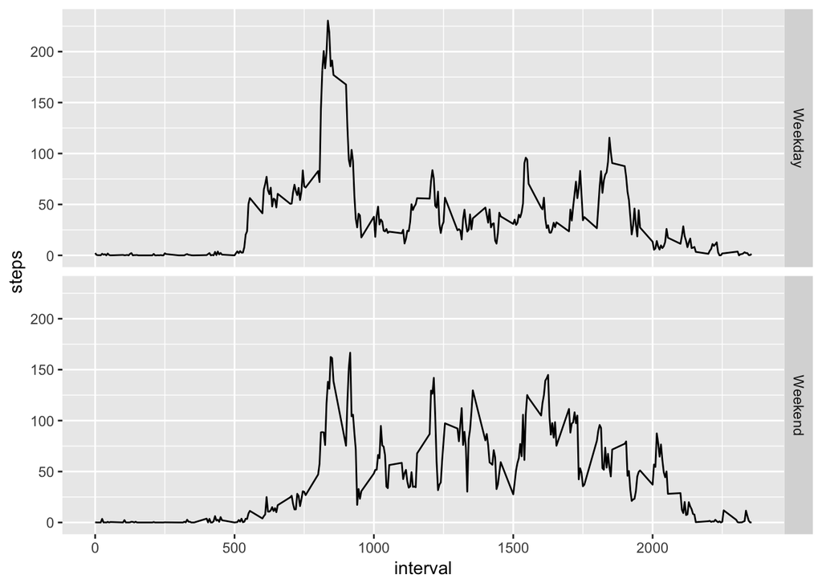

```r
activity_combined <- rbind(activity_weekday_int, activity_weekend_int)
activity_combined$weekend <- as.factor(activity_combined$weekend)
ggplot(activity_combined, aes(interval, steps)) + geom_line() + facet_grid(weekend ~ .)
```